# Indel Signature InsDel8

# InsDel8

(corresponds to 83-type signature C_ID8)

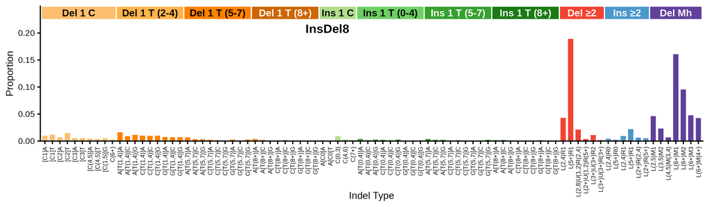

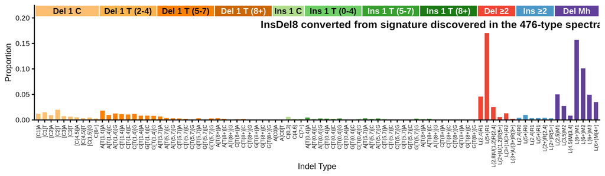

89-type spectrum of the linking tumor CPCT02070336T | cosine similarity to InsDel8: 0.9914

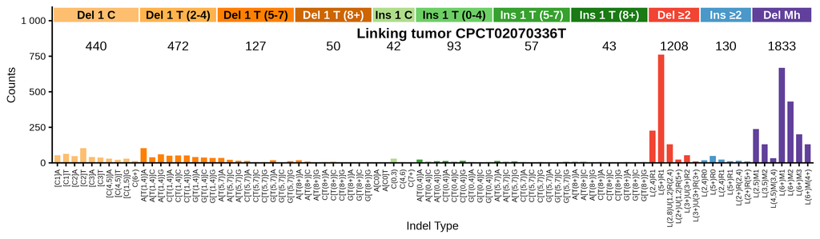

**Click to view decomposition of the linking tumor spectrum**

Partial mutation signature of CPCT02070336T due to InsDel8

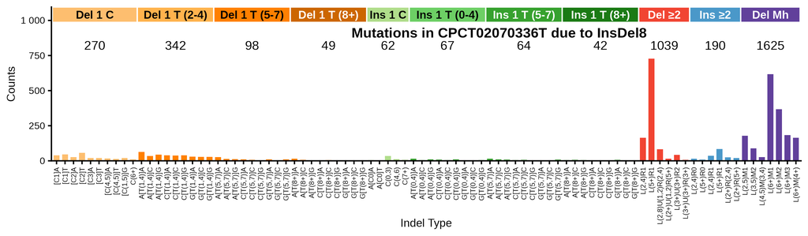

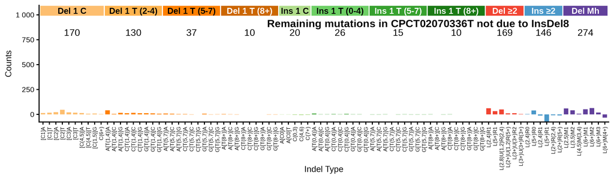

Max neg fraction (maximum allowed negative residual count as fraction of total): 0.04  
N subtract (mutation count assigned to signature): 3847.5  
N residual (mutation count in residual “partial spectrum”): 647.5  
Total negative (sum of negative residual mutation counts): 179.8  
N negative channels (number of channels with negative residual): 26  
P(≥ total negative) (Monte Carlo estimated probability that negative-binomial-sampled spectra from the signature contributing N subtract mutations would produce a total negative count >= the observed Total negative; higher number means not surprising): 0.780

**Per-channel residual breakdown**

| Channel | Spectrum | Sig_Count | Residual | Sig_Prop |
| --- | --- | --- | --- | --- |
| [Del(C):R1]A | 53 | 38.9 | 14.1 | 0.01011 |
| [Del(C):R1]T | 63 | 45.5 | 17.5 | 0.01183 |
| [Del(C):R2]A | 48 | 25.9 | 22.1 | 0.00673 |
| [Del(C):R2]T | 104 | 57.4 | 46.6 | 0.01493 |
| [Del(C):R3]A | 41 | 20.7 | 20.3 | 0.00538 |
| [Del(C):R3]T | 37 | 20.7 | 16.3 | 0.00538 |
| [Del(C):R(4,5)]A | 30 | 16.9 | 13.1 | 0.00439 |
| [Del(C):R(4,5)]T | 21 | 14.1 | 6.9 | 0.00367 |
| [Del(C):R(1,5)]G | 29 | 19.7 | 9.3 | 0.00512 |
| Del(C):R(6,9) | 14 | 9.9 | 4.1 | 0.00258 |
| A[Del(T):R(1,4)]A | 104 | 62.7 | 41.3 | 0.01629 |
| A[Del(T):R(1,4)]C | 40 | 34.8 | 5.2 | 0.00903 |
| A[Del(T):R(1,4)]G | 60 | 44.8 | 15.2 | 0.01165 |
| C[Del(T):R(1,4)]A | 51 | 38.5 | 12.5 | 0.01001 |
| C[Del(T):R(1,4)]C | 52 | 37.2 | 14.8 | 0.00966 |
| C[Del(T):R(1,4)]G | 52 | 39.2 | 12.8 | 0.01018 |
| G[Del(T):R(1,4)]A | 41 | 29.4 | 11.6 | 0.00763 |
| G[Del(T):R(1,4)]C | 38 | 27.5 | 10.5 | 0.00714 |
| G[Del(T):R(1,4)]G | 34 | 28.0 | 6 | 0.00727 |
| A[Del(T):R(5,7)]A | 34 | 26.0 | 8 | 0.00675 |
| A[Del(T):R(5,7)]C | 21 | 13.3 | 7.7 | 0.00347 |
| A[Del(T):R(5,7)]G | 16 | 12.8 | 3.2 | 0.00332 |
| C[Del(T):R(5,7)]A | 14 | 9.7 | 4.3 | 0.00253 |
| C[Del(T):R(5,7)]C | 5 | 6.8 | -1.8 | 0.00178 |
| C[Del(T):R(5,7)]G | 5 | 4.3 | 0.7 | 0.00111 |
| G[Del(T):R(5,7)]A | 18 | 10.7 | 7.3 | 0.00278 |
| G[Del(T):R(5,7)]C | 2 | 4.3 | -2.3 | 0.00113 |
| G[Del(T):R(5,7)]G | 12 | 10.4 | 1.6 | 0.00269 |
| A[Del(T):R(8,)]A | 18 | 15.4 | 2.6 | 0.00400 |
| A[Del(T):R(8,)]C | 9 | 7.8 | 1.2 | 0.00203 |

[output cut: 59 more lines]

**Click to view similar signatures from Koh et al.**

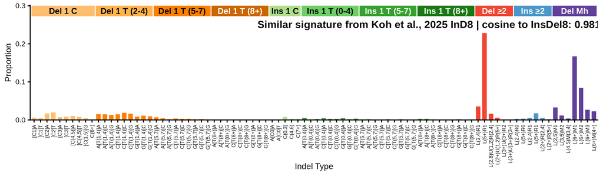

## 476-type representations corresponding to InsDel8

Extracted 476-type signature corresponding to InsDel8

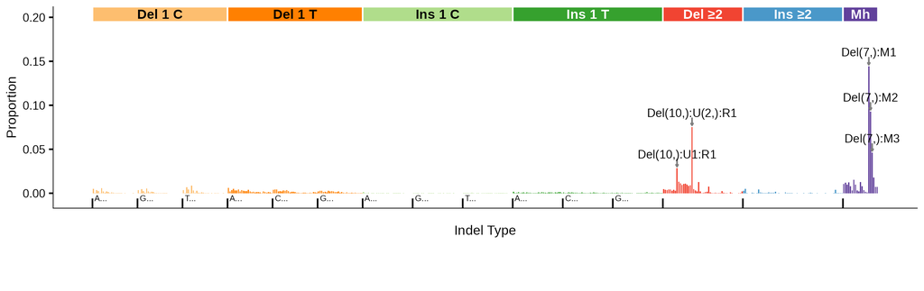

476-type spectrum of the linking tumor CPCT02070336T; cosine similarity to the extracted 476-type signature is 0.9979

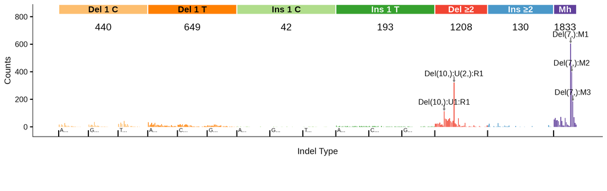

## 83-type signature corresponding to InsDel8 (C_ID8)

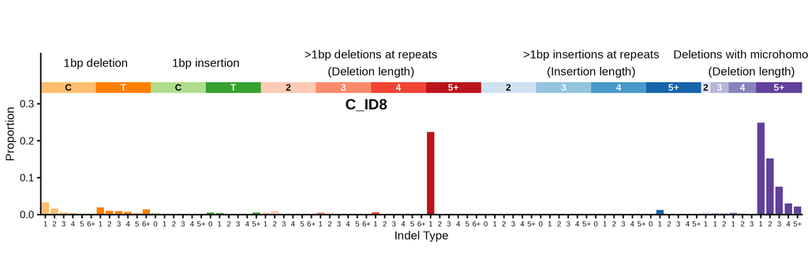

83-type signature converted from signature discovered in the 476-type spectra (using bipartite matching optimization) | cosine similarity to C_ID8: 0.9792

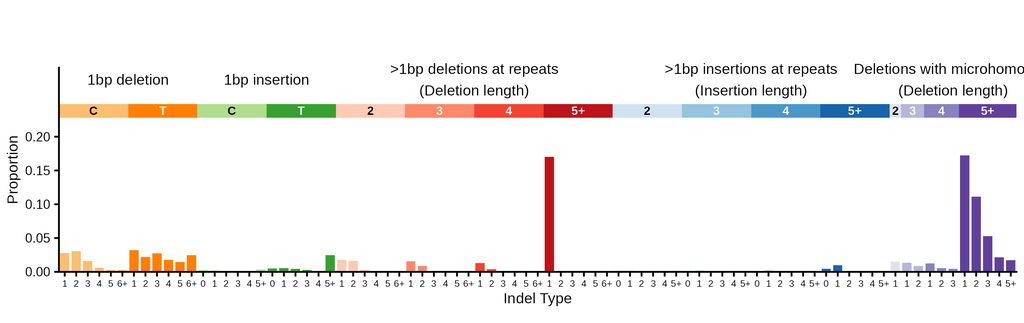

**Click to see flow diagrams: 476-type to 83-type collapse**

These Sankey diagrams show how the 476-type mutation categories are redistributed to 83-type categories using bipartite matching. We only show the diagrams for insertions or deletions of > 1 base because it is for these indels that 476-type categories map to > 1 83-type category.

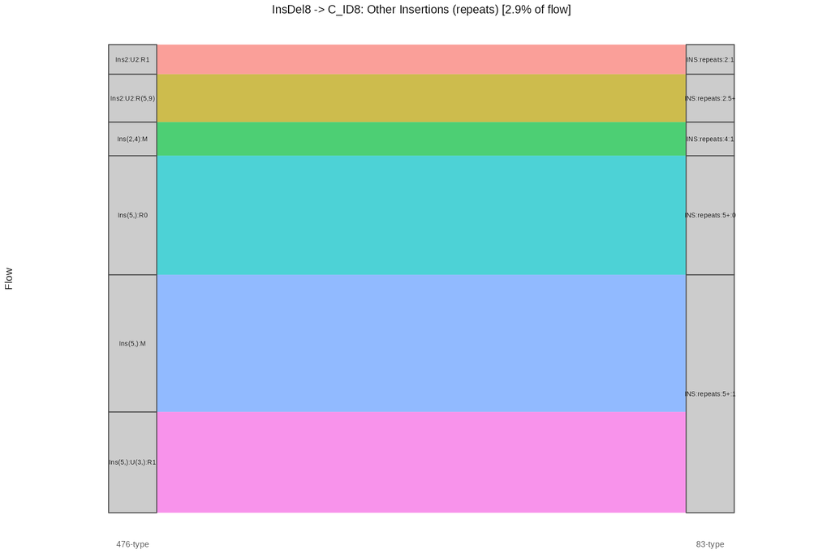

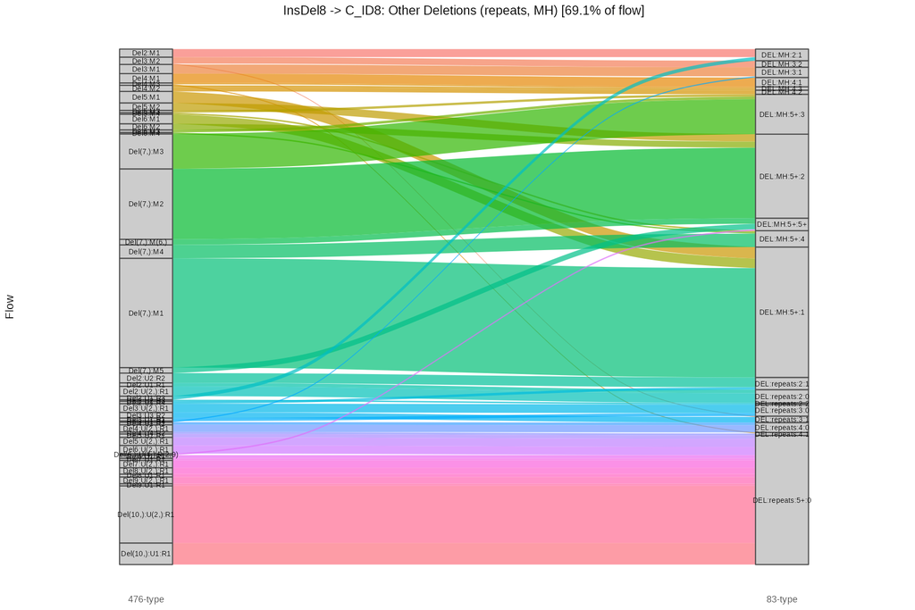

83-type spectrum of the linking tumor CPCT02070336T | cosine similarity to C_ID8: 0.9702

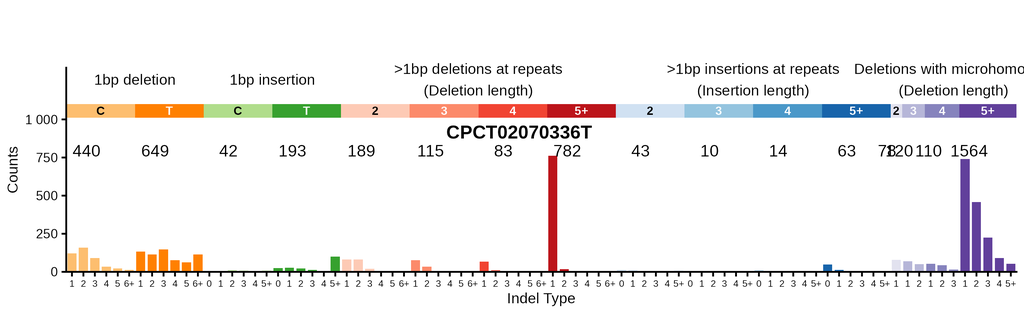

### Similar COSMIC signatures

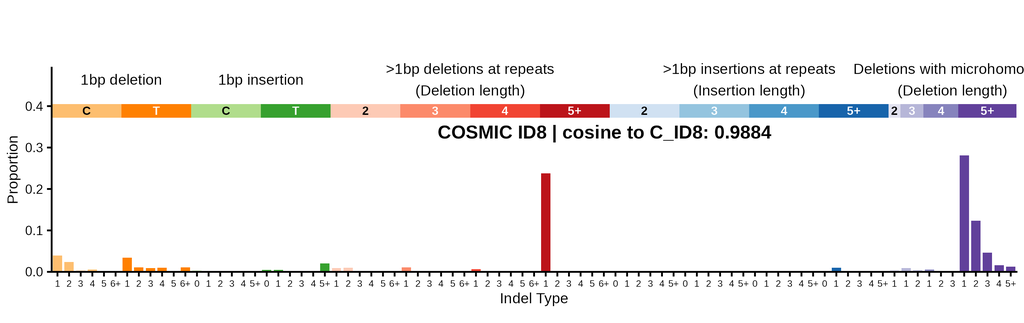

### Similar signatures from Jin et al. 2024

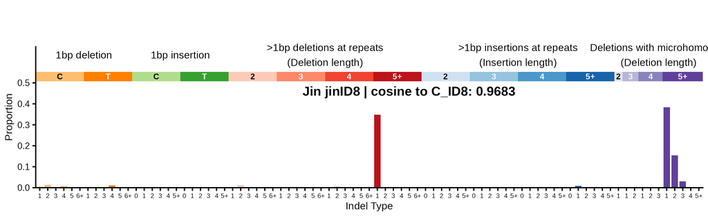